# FloodnetRfa Shiny app

## Introduction

## Objective

- The purpose of this presentation is to guide the user throught the common steps of using the Graphical User Interface (GUI) of the `floodnetRfa` package.
- Compare to the terminal interface, the resulting analysis follows more stricly the Floodnet guidelines.
- The GUI focus on at-site and regional flood frequency analysis of hydrometric gauged stations.

## Main Screens

First, let’s have a quick look at the two mean screen:

## Main Screens

Model: Used for fitting and managing models.

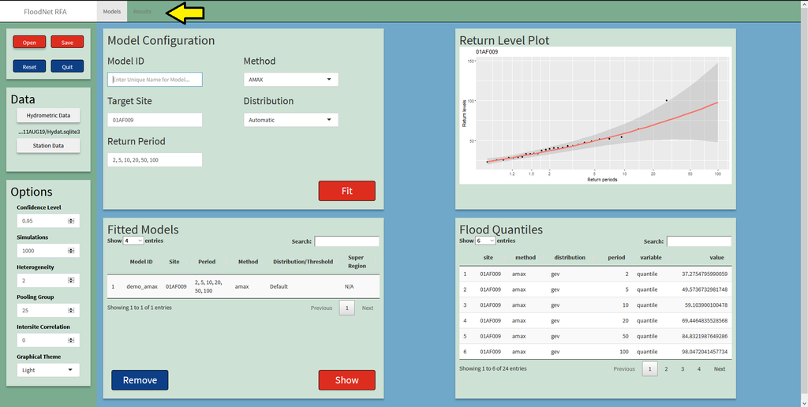

## Main Screens

Resutls: Used to visualized and export model results.

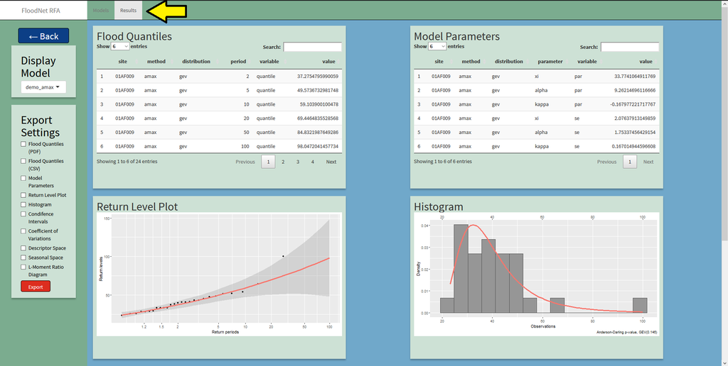

## Table of contents

## Guidelines summaries

## Annual maximum discharge (AMAX)

- The simplest approach to the frequency analysis of extremes, like floods, is to fit a distribution on the sample of annual maxima.
- The distribution can be selected manually or automatically according to the Akaiky Information Criteria (AIC)
- Estimation is done using the method of linear moments (L-moments).
- Dispersion and confidence intervals are evaluated using parametric bootstrap.

## Peaks over threshold (POT)

- A second approach consists to model the peaks above a given threshold using a Generalized Pareto distribution (GPA) with 2 parameters.
- Exceedances are extracted using the declustering method presented by Lang *et al.* 1999
- Estimation is done using the method of maximum likelihood.
- Dispersion and confidence intervals are evaluated using parametric bootstrap.

## Regional Frequency analysis

- Regional estimates are obtained by the Index-flood model using sample mean as scaling factor.
- Estimation is done using the L-moment algorithm introduced by [Hosking and Wallis, 1997](https://www.cambridge.org/core/books/regional-frequency-analysis/8C59835F9361705DAAE1ADFDEA7ECD30#)
- Homogenous regions are formed using pooling groups according to the floodnet guidelines. See [Mostofi and Burn, 2019](https://doi.org/10.1080/07011784.2018.1548946)
- Dispersion and confidence intervals are evaluated using parametric bootstrap.

## Data Input

## Source of information

- The GUI accept two sources of data
  - Hydrometric data that containing streamflow data.
  - Station data that are general information about stations and their basins.
- Hydrometric data
  - The input file is either a CSV file or a locall HYDAT database (sqlite3)
  - The CSV file has 3 columns: Station, Date, Value.
  - Station is a unique identifiant (alphanumeric).
  - The date must be in a valid format (e.g. `'2020-07-15'`)
  - Depending on the analysis, the values can be annual maxima or daily discharges.

## Source of information

- Station data are meta information about stations.
  - Needed only for Reginal Frequency Analysis (RFA)
  - The input must be a CSV file.
  - Each row represent a station with multiple attributes in column.
- List of attributes
  - Station ID. Same as in hydrometric data
  - Drainage area in \(km^2\).
  - Mean annual precipitation (MAP) in \(mm\).
  - Super Region.
  - Threshold (only for RFA POT)

## Data Panel

Use the two buttons to select data input.

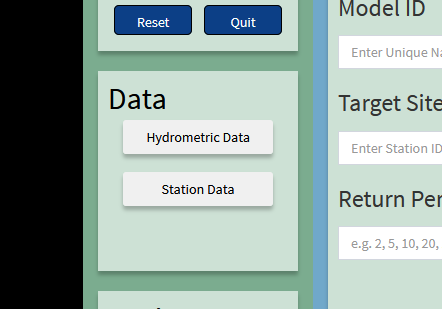

## Data Panel

A explorer windows will appear. Select the desired file.

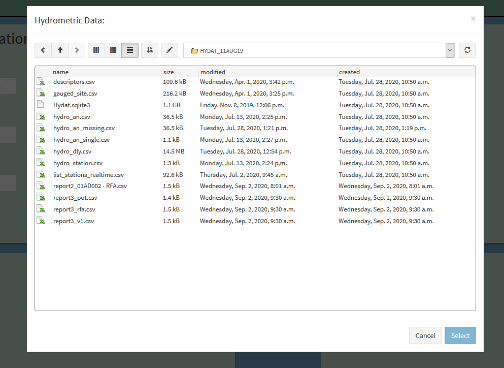

## Data Panel

When the file is selected the name appears below the button.

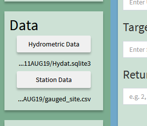

## Fitting models

## Model Configuration

The model configuration panel is used to configure the desired model. Once configured, press the `Fit` button.

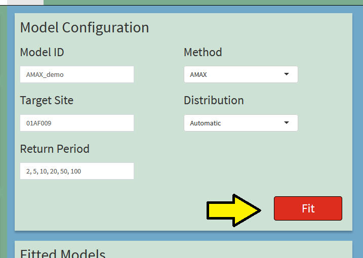

## Model Configuration

- Model ID: Identifiant of the model. Must be unique and meaningful.
- Method: Method use to perform the frequency analysis.
- Target Site: Station of interest. Must correspond to the ID of one hydrometric station.
- Return period: List of return periods separated by a comma, and for which flood quantiles will be evaluated.

## Model Configuration (AMAX)

- For an AMAX analysis the distribution must be selected.
- There are four distribution choices:
  - Generalized Extreme Values(GEV)
  - Generalized Logistic (GLO)
  - Generalized Normal (GNO)
  - Pearson type III (PE3)
- A best distribution can be automatically selected using AIC.

## Model Configuration (AMAX)

Select the distribution using the drop-down list

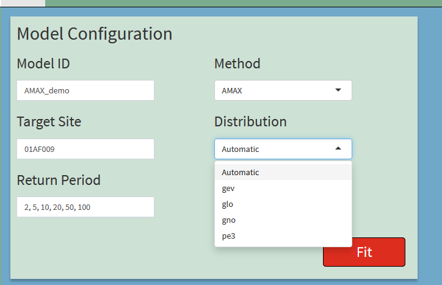

## Model Configuration (POT)

No distribution is selected for POT. However, a threshold must be passed manually or automatically according to the procedure developed by [Durocher *et al.*, 2018](https://onlinelibrary.wiley.com/doi/abs/10.1002/hyp.13223)

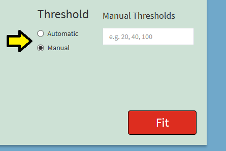

## Model Configuration (RFA)

For RFA the user must select a `Super Regions`. It corresponds to a column of the station data that classified all stations. Only the stations inside the same super region as the target site are considered for forming the pooling groups.

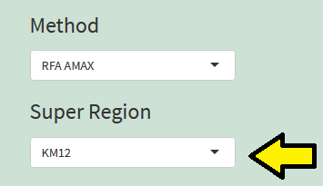

## Return level Plot

After pressing the `Fit` button, the graphics of the flood quantiles (Return Levels) with respect of the return period is produced for assessing the quality of the fitted model.

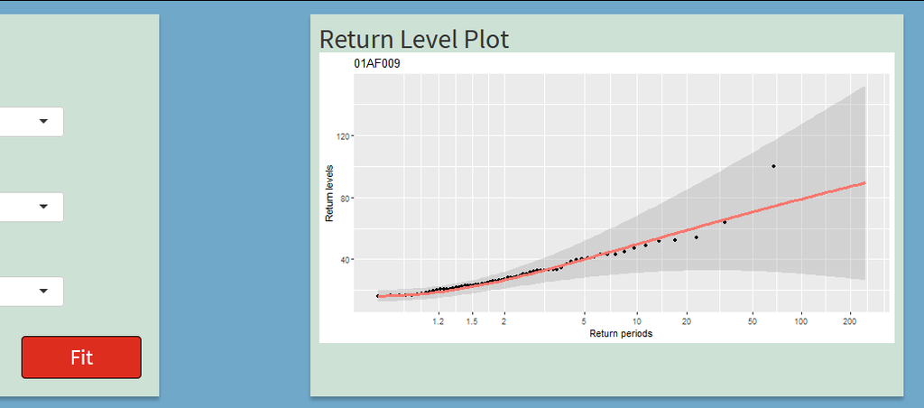

## Flood quantile

The flood quantiles are also presented in the form of a table.

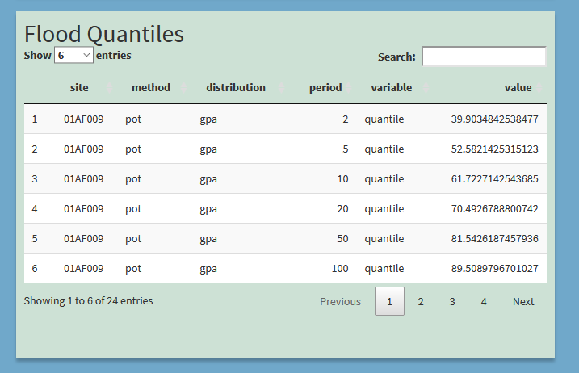

## Flood quantile

The standard error (se) and the confidence intervals (lower, upper) are also available.

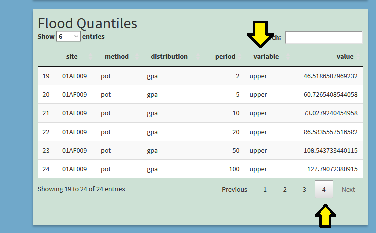

## Model management

## Fitted Models

After pressing the `Fit` button, the fitted model is added to a list, where each entry is identified by the `Model ID`.

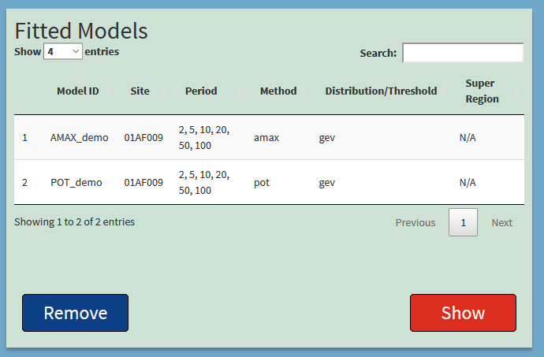

## Fitted Models

- One or more model can be selected by clicking the list.
- Selected models can be removed from the list using the `Remove` button.
- Or further results are presented by clicking on the `Show` button.

## Saving models

- A list of fitted models can be saved using the `Save` buttons.
- A file explorer will open and allow you to select where to save the models
- The saved models are saved in common R format: `.Rdata`.
- The `Open` button will load previously saved models.
- The `Reset` button will empty the current list of model.

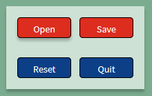